介入學會 · Carotid Stenting Course

# Post-Carotid Stenting Surveillance

Follow-up imaging, duplex velocity criteria for in-stent restenosis, and when to re-intervene after CAS

謝慕揚 MD, PhD, FESC Structural & Interventional Cardiology Weekend Course · 2026

01 · The Problem

## The stent is placed — the risk is not over

CAS treats the lesion of the day. Restenosis, plaque progression and recurrent embolic events develop *silently* over the months and years that follow. Structured surveillance is how we catch them before the next stroke.

~6%restenosis / occlusion at 2 years after CAS (CREST)

>50%of restenoses are asymptomatic — imaging, not symptoms, finds them

CAS fixes the lesion — but the stented internal carotid, and the rest of the vascular tree, still need watching.

Why it matters Most ISR is clinically silent until it embolises or occludes. Surveillance converts an unpredictable late event into a **scheduled, treatable finding**.

Lal BK, et al. *Lancet Neurol.* 2012.02

02 · Roadmap

## What this talk covers

A

### What we watch for

ISR, recurrent stroke, contralateral progression, stent & access issues.

B

### How & when

Duplex-first schedule, baseline scans, and the role of CTA / MRA / DSA.

C

### Reading the duplex

Stent-specific velocity criteria — why native thresholds mislead.

D

### Acting on it

Medical therapy, thresholds for re-intervention, treatment options.

E

### Guidelines

SVS 2022 / ESVS 2023 surveillance recommendations at a glance.

F

### Worked cases

Two contrasting examples — the *watch* pathway vs the *act* pathway.

Post-CAS Surveillance03

01

## What are we watching for?

The targets of surveillance after CAS

01 · Targets

## Six things to look for at follow-up

### In-stent restenosis

Neointimal hyperplasia → recurrent narrowing. The #1 surveillance target.

### Recurrent ipsilateral stroke / TIA

Embolic or flow-limiting. Symptoms always override imaging.

### Contralateral progression

Atherosclerosis is bilateral — the other side can advance silently.

### Hyperperfusion syndrome

Early (hours–days): headache, seizures, ICH after flow restoration.

### Stent integrity

Fracture, deformation, incomplete apposition — rare but late risk.

### Access & systemic

Groin/radial access site, plus global vascular risk-factor control.

Anchor Surveillance has two arms running in parallel: **imaging of the stented vessel** and **clinical neurologic assessment**. Neither alone is enough.

What we watch for05

01 · In-Stent Restenosis

## Definition & incidence

- **Mechanism differs from native disease.** Early/intermediate ISR is *neointimal hyperplasia* (smooth-muscle proliferation), not lipid-rich plaque — smoother, more concentric, less embolic than de-novo lesions.
- **Two clinically used thresholds:** *≥50%* (moderate, watch) and *≥70–80%* (severe, act).
- **Timing:** highest hazard in the first *12–24 months*; very late restenosis tends to be recurrent atherosclerosis.
- **Behavior:** a majority remain asymptomatic; stroke risk from ISR is lower than from primary plaque but not zero.

Concentric neointimal (smooth-muscle) ingrowth inside the stent. Severe ISR (≥70%) ~3–6% at 1–2 yr; ISR-related stroke <1–2%/yr — lower & less embolic than de-novo plaque.

Teaching point Reported ISR rates swing widely (≈3–30%) **because the definition and the duplex criteria differ between studies**. Always state which threshold you mean.

Lal BK, et al. *Lancet Neurol.* 2012.06

01 · Risk Stratification

## Who restenoses? — risk factors for ISR

### Patient / biology

Female sex · diabetes · active smoking · dyslipidaemia · chronic kidney disease · **prior neck radiation** (radiation-induced stenosis is high-risk).

### Lesion / anatomy

Small reference diameter · long lesion · severe baseline calcification · recurrent (post-CEA) stenosis.

### Procedure

**Residual in-stent stenosis (≥~30%)** after stenting · stent malapposition · multiple overlapping stents.

### Adherence

Antiplatelet non-compliance · uncontrolled risk factors · statin under-treatment.

Practical use High-risk patients (radiation, residual stenosis, post-CEA, diabetic) earn a **tighter surveillance interval** — not the same one-size schedule.

Lai PMR, et al. *Neurosurgery.* 2023 (residual ≥~30% → ISR).07

01 · Natural History

## A timeline of risk — different problems, different windows

Early · 0–30 days

### Procedural & hemodynamic

Acute/subacute stent thrombosis, embolic events, **cerebral hyperperfusion syndrome**, access-site complications, bradycardia/hypotension.

Intermediate · 1–24 mo

### Neointimal hyperplasia

The dominant ISR mechanism. Smooth-muscle proliferation peaks — this is the window your duplex surveillance is built around.

Late · >2 years

### Atherosclerosis & integrity

Recurrent atherosclerotic restenosis, contralateral progression, **stent fracture** / deformation. Justifies indefinite annual follow-up.

Mental model Match the **modality and interval** to the phase: dense early clinical vigilance → duplex through the hyperplasia window → lifelong annual checks.

Timeline of risk08

02

## How & when to image

The surveillance schedule and the duplex toolkit

02 · Schedule

## A practical surveillance schedule

Representative schedule consistent with SVS 2022 / ESVS 2023; tighten intervals for high-risk anatomy or a rising-velocity trend.

| Time point | Modality | Purpose | Action |
| --- | --- | --- | --- |
| **Baseline — ≤30 days** | Duplex US | Establish *this patient's* post-stent velocities + check residual stenosis | Mandatory reference scan |
| 6 months | Duplex US | Catch early neointimal hyperplasia | Compare to baseline |
| 12 months | Duplex US | Peak-hazard window | Compare trend |
| Annually thereafter | Duplex US | Late restenosis, contralateral disease, stent integrity | Indefinite if stable |
| Any new symptom | Duplex ± CTA/DSA | TIA/stroke in the territory | Expedite — do not wait |

Do not skip The **baseline (≤30-day) duplex** is the single most useful scan — without it, every later velocity is uninterpretable.

Surveillance schedule09

02 · Modality of choice

## Duplex ultrasound is the workhorse

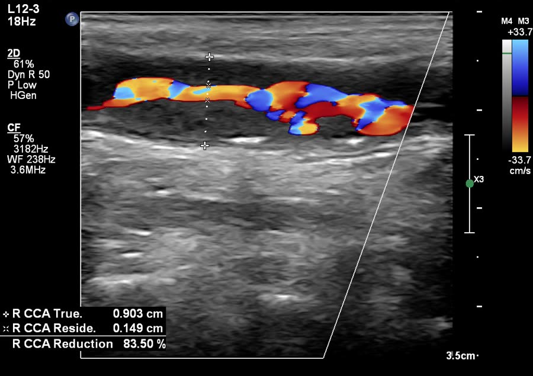

**Color Doppler.** Flow direction & turbulence — mosaic / aliasing marks the stenosis. The *anatomy & lumen* layer.

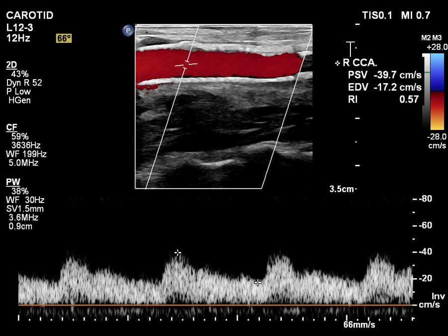

**Spectral Doppler.** PSV / EDV / ICA–CCA ratio — the *physiology* layer that actually grades the stenosis.

- **Non-invasive, no contrast, no radiation** — ideal for repeated, lifelong follow-up.
- One bedside test gives both *anatomy* (B-mode / color) and *physiology* (spectral velocities), and tracks the rising-velocity *trend* that flags ISR.

But — one big caveat A stent **stiffens the artery**, raising measured velocities *even with a widely patent stent*. Apply native thresholds and you **over-call restenosis** — so use a lab that validates its own stented criteria.

Duplex ultrasound10

02 · The Pitfall

## Why native-artery velocity thresholds mislead in a stent

- **Stent = a rigid tube.** Loss of pulsatile wall expansion increases peak systolic velocity for the *same lumen*.
- The effect is largest **early after deployment** and in long / stiff constructs.
- Net result: a normal stented ICA often shows velocities that would mean “50% stenosis” in a native vessel.
- **The fix:** use *stent-specific, elevated cutoffs* and weigh the *serial trend* over any single absolute number.

[figure not shown]

Same lumen, stiffer wall → higher PSV. The stented artery needs its own, higher cutoffs (next slide).

Lal BK; AbuRahma AF; Setacci C. *J Vasc Surg* / *Stroke*, 2008.11

02 · The Key Slide

## Stent-specific duplex criteria for ISR

Representative validated cutoffs (e.g. AbuRahma, Lal et al.). Exact thresholds vary by study — every lab should validate & state its own. Note these run markedly higher than native-ICA criteria.

| Degree of in-stent restenosis | Peak systolic velocity (PSV) | ICA / CCA ratio | EDV (guide) |
| --- | --- | --- | --- |
| Normal / <20% (baseline) | < 150 cm/s | < 2.0 | — |
| ≥ 50% (moderate — *watch closely*) | ≥ 220 cm/s | ≥ 2.7 | ≥ 70 cm/s |
| ≥ 70–80% (severe — *act*) | ≥ 300–340 cm/s | ≥ 4.0 | ≥ 100–125 cm/s |

### Use the ratio

ICA/CCA ratio is **less stiffness-dependent** than absolute PSV — a robust tie-breaker.

### Use the trend

A velocity **climbing across serial scans** beats any single value for calling early ISR.

### Confirm before acting

Severe by duplex → confirm with **CTA or DSA** before re-intervention.

Lal BK 2008 · AbuRahma AF 2008 · Setacci C 2008. *J Vasc Surg* / *Stroke*.12

02 · Interpretation

## Baseline first, then trust the trend

- **Record a baseline PSV/EDV/ratio for each patient** at ≤30 days — the stent's own “normal.”
- Judge later scans against that baseline, not a population number.
- **A doubling of PSV** or a clear upward trajectory is a red flag even below the absolute severe cutoff.
- Keep *the same lab and protocol* where possible — inter-lab variability is real.

Baseline & trend13

02 · Escalation

## When duplex is not enough — confirmatory imaging

### CT angiography

**Strengths:** fast, anatomic, arch & intracranial run-off.  
**Watch:** stent **blooming / artifact** can overstate stenosis; needs contrast.

### MR angiography

**Strengths:** no iodinated contrast / radiation.  
**Watch:** **susceptibility artifact** from the stent; tends to overestimate.

### Catheter DSA

**Gold standard** for quantifying ISR and **planning re-intervention**. Invasive — reserve for equivocal or treatment-bound cases.

Sequence Duplex screens → CTA/MRA confirms anatomy when duplex is equivocal or severe → **DSA when you intend to treat**.

Confirmatory imaging14

03

## Acting on the findings

Medical therapy, thresholds, and re-intervention

03 · Decision

## Managing in-stent restenosis

| Scenario | Default action | Notes |
| --- | --- | --- |
| Asymptomatic, < 70% | **Intensify medical Rx + close surveillance** | Most ISR; re-image in a shortened interval |
| Symptomatic (TIA/stroke), any severe | Re-intervention | Symptoms drive the decision |
| Asymptomatic, ≥ 70–80% | Consider re-intervention | Individualise: progression rate, anatomy, risk |

### Balloon angioplasty

First-line for ISR; **drug-coated balloons** increasingly used to limit recurrence.

### Repeat stenting

For elastic recoil or dissection; adds another layer of metal — weigh carefully.

### Surgery (CEA / stent explant)

Reserved & technically demanding; selected refractory or recurrent cases.

Honest caveat Evidence for ISR treatment is **limited and largely observational** — decisions are individualised in a heart/vascular team.

Managing ISR15

03 · Foundation

## Medical therapy underpins every surveillance plan

### Antiplatelet therapy

**DAPT** (aspirin + clopidogrel) for ~**1 month** post-CAS, then lifelong single agent — per device & local protocol.

### High-intensity statin

Aggressive LDL lowering (± ezetimibe / PCSK9i). Plaque stabilization lowers restenosis & stroke.

### Risk-factor control

**BP**, **glycaemic** control, and **smoking cessation** — each independently drives ISR risk.

### Adherence & education

Reinforce at every visit. Teach the patient the **warning symptoms** of TIA/stroke.

Frame Surveillance imaging **detects** trouble; optimized medical therapy is what **prevents** it. Do both.

Medical therapy16

03 · Guidelines

## Where the guidelines land

Schedules are broadly concordant; specifics & recommendation grades differ — consult the current full text for exact wording.

| Source | Surveillance imaging | Emphasis |
| --- | --- | --- |
| **SVS 2022** (Society for Vascular Surgery) | Duplex: baseline, ~6 & 12 mo, then annual | Duplex-led; treat severe/symptomatic ISR |
| **ESVS 2023** (European Society for Vascular Surgery) | Duplex follow-up; investigate rising velocity / symptoms | Stent-specific criteria; selective re-intervention |
| **AHA / ASA** | Periodic non-invasive imaging post-revascularisation | Best medical therapy + risk-factor control |

Common thread Every society converges on the same spine: **baseline duplex → periodic duplex → escalate on symptoms or a rising-velocity trend**, all on a foundation of optimal medical therapy.

AbuRahma AF, et al. *J Vasc Surg.* 2022 · Naylor R, et al. *Eur J Vasc Endovasc Surg.* 2023.17

03 · Putting it together

## A one-page surveillance algorithm

1

**Post-CAS** — baseline duplex at ≤30 days: record PSV / EDV / ICA-CCA ratio.

▼

2

**Serial duplex** at 6 & 12 months, then **annually**. Compare every scan to baseline.

▼

3

**Interpret** with **stent-specific cutoffs** + the trend — not native thresholds.

▼

**Stable & asymptomatic**  
Continue annual duplex · optimize medical therapy.

**Rising velocity / severe / symptoms**  
Confirm with CTA ± DSA → team decision on re-intervention.

Surveillance algorithm18

04

## Cases from practice

Two real, de-identified cases — watching the stent, acting on the other side

Case 1 · Surveillance journey

## One patient, two lessons: a quiet stent and a noisy other side

- Severe **bilateral** internal-carotid stenosis with reversed ophthalmic collaterals — a clear indication to revascularise.
- **Right ICA stented first** (index CAS). The left carotid was significant too and was kept under *duplex surveillance*.
- For 3 years surveillance ran **two parallel questions**: is the *stent* restenosing, and is the *contralateral* side advancing?
- Answer: the stent stayed wide open — but the **other side** became the next intervention.

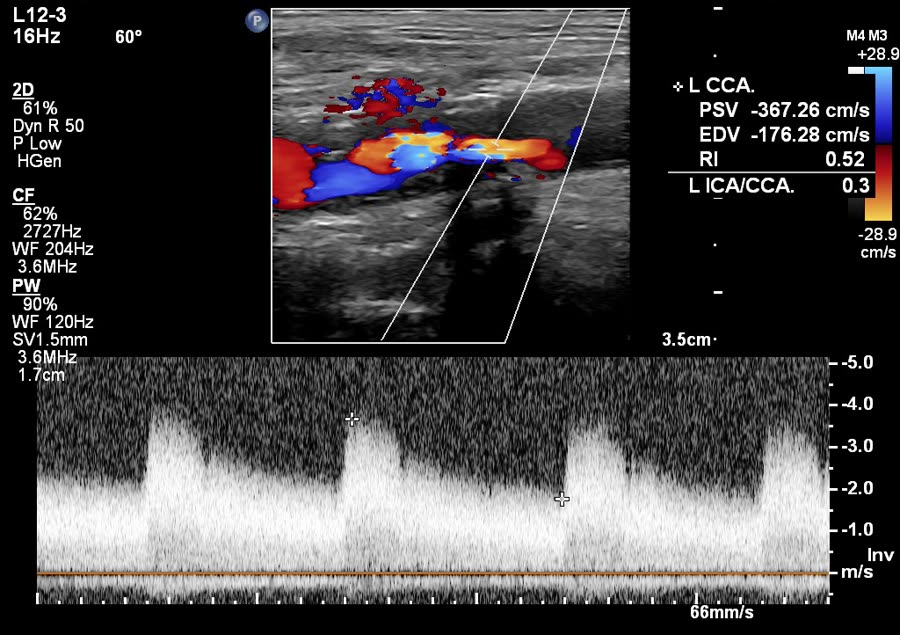

Baseline

Severe bilateral stenosis

Month 0

Right ICA stent (index CAS)

~16 mo

~20 mo

Contralateral (left) angioplasty

~3 yr

Stent patent · left improved

Case 1 · Overview19

Case 1 · The index procedure

## Why the stent went in — and the immediate result

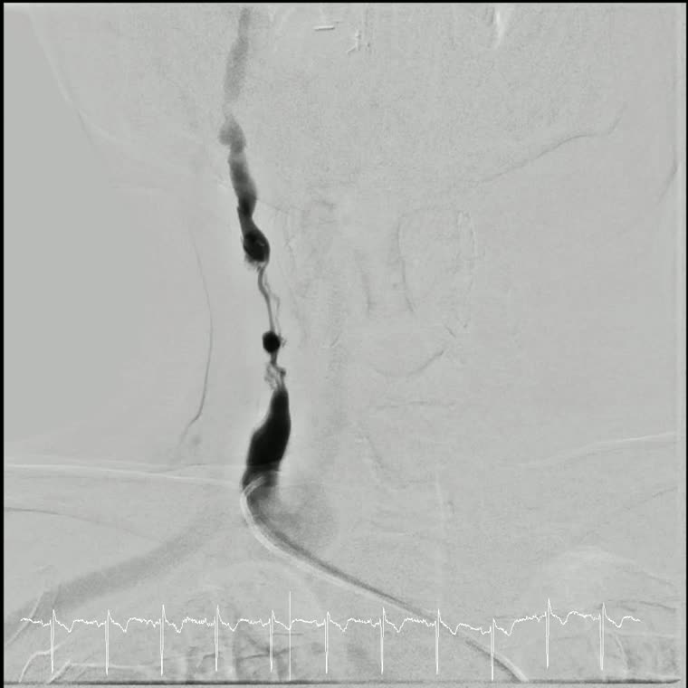

**Pre-stent DSA.** Tight, irregular stenosis of the cervical internal carotid with post-stenotic change.

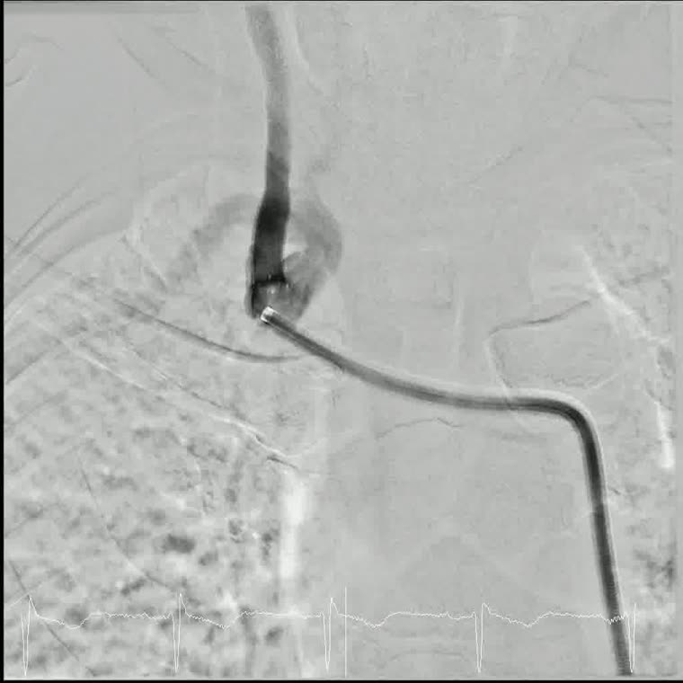

**Post-stent.** Self-expanding stent across the lesion — lumen restored, brisk antegrade flow.

Set the baseline The post-procedure angiogram — and a **≤30-day baseline duplex** — define *this* stent's “normal.” Every later velocity is read against it.

Case 1 · Index CAS20

Case 1 · In-stent restenosis watch

## Reading the stent — with stent-specific criteria

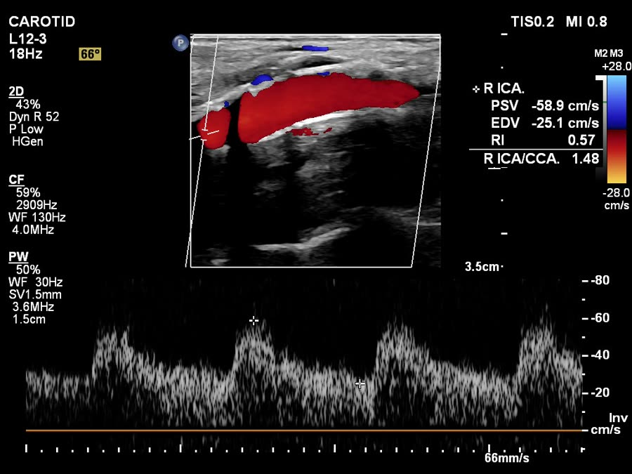

**In-stent ICA · ~3 yr.** PSV 59 cm/s · ICA/CCA 1.48 · laminar fill.

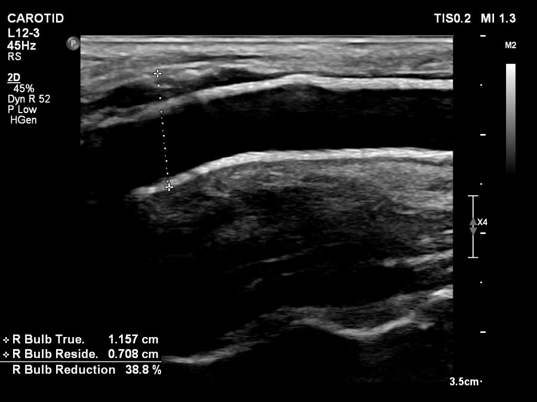

**B-mode.** Bright stent struts, thin uniform neointima — no flow-limiting tissue.

PSV in cm/s. Stent-specific thresholds (see the key-criteria slide).

| Visit | In-stent PSV | ICA/CCA | Read |
| --- | --- | --- | --- |
| ~16 mo | 49 | 1.1 | patent |
| ~3 yr | 59 | 1.48 | patent |
| ISR ≥50% cutoff | ≥220 | ≥2.7 | not reached |

Teaching point Velocities sit **far below** the stent ISR thresholds, are stable across scans, and the struts look clean → **no in-stent restenosis**. The point is not the low number — it is knowing you are holding the *stent* ruler, not the native one.

Case 1 · No in-stent restenosis21

Case 1 · Contralateral disease progression

## The stent was fine — the *other* side wasn't

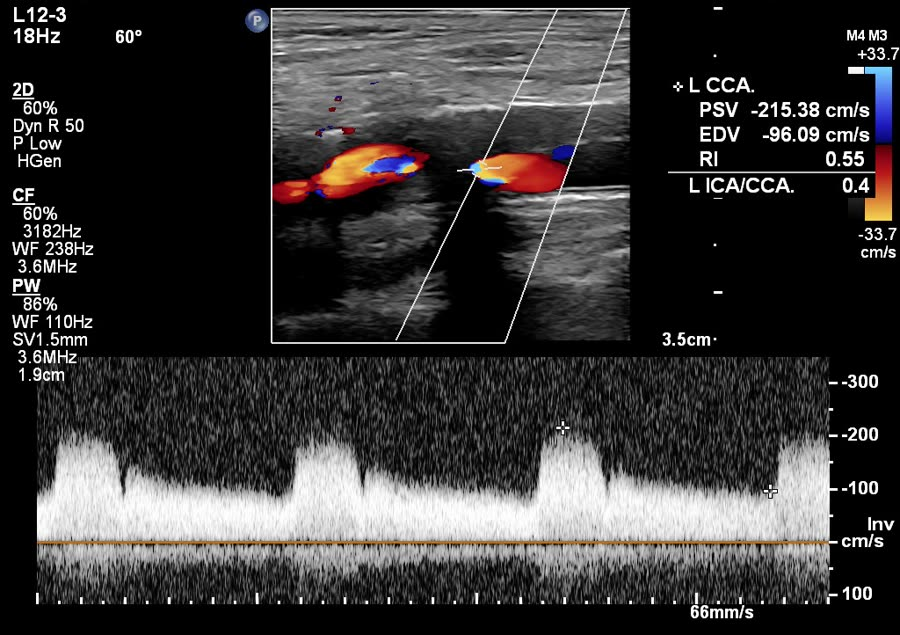

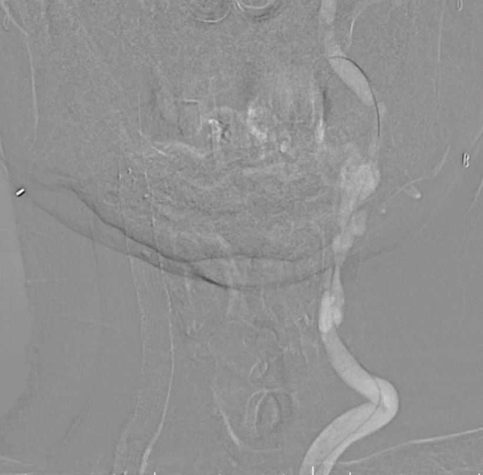

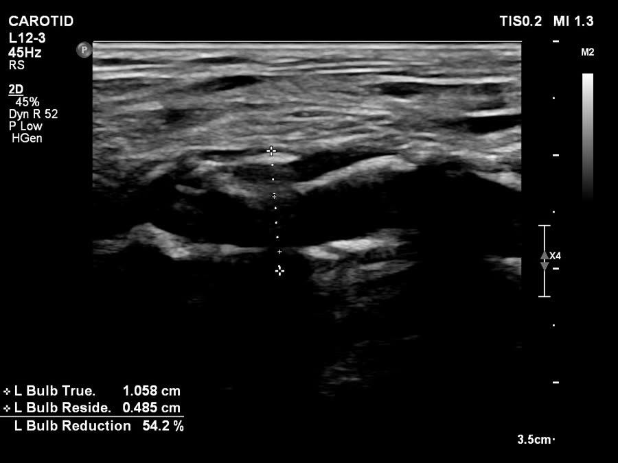

- **Atherosclerosis is bilateral.** A perfect stent does not protect the contralateral artery.
- Surveillance here **scanned both sides at every visit** — that is what caught the left.
- The **untreated side, not the stent,** became the next intervention — then settled after treatment.

Why it matters Post-CAS surveillance is **not just stent-watching**. Track the contralateral carotid (and the vertebrals) on the same schedule — progression there changes management.

Leopardi M, et al. *J Vasc Surg.* 2020 · AbuRahma AF, et al. *J Vasc Surg.* 2022.22

Case series · What the literature shows

## In-stent restenosis: how common, and does it cause strokes?

- **CREST** (2,191 randomized): restenosis / occlusion at 2 yr **6.0% after CAS** vs 6.3% after CEA — *low and not different*. Predictors: female sex, diabetes, dyslipidaemia.
- **450 CAS, mean 70-mo duplex follow-up:** progression to ≥50% in-stent stenosis in **27%**, to ≥80% in **8.7%**.
- Yet only **2.7%** had an ipsilateral TIA/stroke — most ISR is *silent*, so surveillance can be **selective** and risk-based.

Lal BK, et al. *Lancet Neurol.* 2012 · AbuRahma AF, et al. *J Vasc Surg.* 2022.23

Case series · When ISR needs action

## Treating severe in-stent restenosis — the drug-coated balloon

Carotid ISR evidence is observational (no RCT). DCB = drug-coated balloon. PSV in m/s as reported.

| Series | n | Setting | Stenosis (pre → post) | PSV (pre → post) | Follow-up |
| --- | --- | --- | --- | --- | --- |
| **Montorsi 2012** | 7 | first ISR · IVUS-guided DCB, distal protection | 83% → 18% | 4.0 → 0.9 m/s | 13.7 mo · **no restenosis** |
| **Gandini 2014** | 9 | *refractory recurrent* ISR (mean 3.4 prior Rx) | 87% → 6% | 4.7 → 0.6 m/s | 36.6 mo · TVR 33% |

- **Balloon angioplasty — increasingly drug-coated — is first-line** for severe/symptomatic ISR, under embolic protection.
- **First-time ISR** responds well; *recurrent* ISR is the hard problem — up to **1 in 3** need repeat treatment by 3 yr.

Decision rule Asymptomatic <70% → intensify medical Rx + tighten surveillance. **Symptomatic or ≥70–80% → confirm (CTA/DSA) and treat**, DCB first.

Montorsi P, et al. *J Endovasc Ther.* 2012 · Gandini R, et al. *J Endovasc Ther.* 2014.24

Summary

## Five things to walk out with

- **Surveillance is non-negotiable** — most in-stent restenosis is silent until it causes a stroke.
- **Duplex is the workhorse**, on a baseline → 6 & 12 mo → annual schedule.
- **Use stent-specific velocity criteria** (PSV ≥220 for ≥50%, ≥300–340 for ≥70%) — native thresholds over-call.
- **Trend > single number;** a personal baseline makes every later scan interpretable.
- **Symptoms drive re-intervention;** confirm with CTA/DSA, and never stop optimizing medical therapy.

Take-home messages25

References

## Key references

1. **Lal BK, Beach KW, Roubin GS, et al.** Restenosis after carotid artery stenting and endarterectomy: a secondary analysis of CREST. *Lancet Neurol.* 2012;11(9):755–763. — doi.org/10.1016/S1474-4422(12)70159-X
2. **Lai PMR, Baig AA, Khawar WI, et al.** Residual in-stent carotid stenosis and cigarette smoking are independent predictors of carotid restenosis after carotid artery stenting (738 procedures). *Neurosurgery.* 2023. — doi.org/10.1227/neu.0000000000002798
3. **Lal BK, Hobson RW 2nd, Tofighi B, et al.** Duplex ultrasound velocity criteria for the stented carotid artery. *J Vasc Surg.* 2008;47(1):63–73. — doi.org/10.1016/j.jvs.2007.09.038
4. **AbuRahma AF, Abu-Halimah S, Bensenhaver J, et al.** Optimal carotid duplex velocity criteria for defining the severity of carotid in-stent restenosis. *J Vasc Surg.* 2008;48(3):589–594. — doi.org/10.1016/j.jvs.2008.04.004
5. **Setacci C, Chisci E, Setacci F, et al.** Grading carotid intrastent restenosis: a 6-year follow-up study. *Stroke.* 2008;39(4):1189–1196. — doi.org/10.1161/STROKEAHA.107.497487
6. **AbuRahma AF, Avgerinos ED, Chang RW, et al.** SVS clinical practice guidelines for management of extracranial cerebrovascular disease. *J Vasc Surg.* 2022;75(1S):4S–22S. — doi.org/10.1016/j.jvs.2021.04.073
7. **Naylor R, Rantner B, Ancetti S, et al.** ESVS 2023 Clinical Practice Guidelines on the management of atherosclerotic carotid and vertebral artery disease. *Eur J Vasc Endovasc Surg.* 2023;65(1):7–111. — doi.org/10.1016/j.ejvs.2022.04.011
8. **AbuRahma AF, Santini AG, AbuRahma ZT, et al.** Rates of progression of carotid in-stent stenosis and clinical outcomes. *J Vasc Surg.* 2022;76(6):1596–1602. — doi.org/10.1016/j.jvs.2022.07.002
9. **Montorsi P, Galli S, Ravagnani PM, et al.** Drug-eluting balloon for in-stent restenosis after carotid artery stenting. *J Endovasc Ther.* 2012;19(6):734–742. — journals.sagepub.com/doi/10.1583/JEVT-12-4042R.1
10. **Gandini R, Del Giudice C, Da Ros V, et al.** Long-term results of drug-eluting balloon angioplasty for refractory recurrent carotid in-stent restenosis. *J Endovasc Ther.* 2014;21(5):671–677. — journals.sagepub.com/doi/10.1583/14-4715MR.1
11. **Leopardi M, Bisogno F, Maggipinto A, et al.** A systematic review of contralateral carotid stenosis progression after carotid endarterectomy. *J Vasc Surg.* 2020;72(6):2167–2173. — doi.org/10.1016/j.jvs.2020.07.095

References26

Thank you

# Questions & Discussion

Post-Carotid Stenting Surveillance — baseline duplex, stent-specific criteria, treat the trend.

謝慕揚 MD, PhD, FESC 介入學會 · Carotid Stenting Course · 2026